# WP1 - metadata analyses

Remy Beugnon

1/21/2022

# Missing coordinates

| name | site | number |
| --- | --- | --- |
| Jonas Lembrechts | 54705 | 4 |
| Jonas Lembrechts | 54706 | 4 |
| Jonas Lembrechts | 54749 | 4 |
| Jonas Lembrechts | 54750 | 4 |
| Jonas Lembrechts | 54751 | 4 |
| Jonas Lembrechts | 54752 | 4 |
| Jonas Lembrechts | 54753 | 4 |
| Jonas Lembrechts | 54754 | 4 |
| Jonas Lembrechts | 54755 | 4 |
| Jonas Lembrechts | 54756 | 4 |
| Jonas Lembrechts | 54757 | 4 |
| Jonas Lembrechts | 54758 | 4 |
| Jonas Lembrechts | 54759 | 4 |
| Jonas Lembrechts | 54760 | 4 |
| Jonas Lembrechts | 54761 | 4 |
| Jonas Lembrechts | 54762 | 4 |
| Jonas Lembrechts | 54763 | 4 |
| Jonas Lembrechts | 54764 | 4 |
| Jonas Lembrechts | 54765 | 4 |
| Jonas Lembrechts | 54766 | 4 |
| Jonas Lembrechts | 54767 | 4 |
| Jonas Lembrechts | 54768 | 4 |
| Jonas Lembrechts | 54769 | 4 |
| Jonas Lembrechts | 54770 | 4 |
| Jonas Lembrechts | 54771 | 4 |
| Jonas Lembrechts | 54772 | 4 |
| Jonas Lembrechts | 54773 | 4 |
| Jonas Lembrechts | 54774 | 4 |
| Jonas Lembrechts | 54775 | 4 |
| Jonas Lembrechts | 54776 | 4 |

[output cut: 193 more lines]

# Loggers height selection

| height | number.of.loggers |
| --- | --- |
| < -1000 | 5 |
| >= -1000 & < -500 | 3 |
| >= -500 & < -100 | 39 |
| >= -100 & < -50 | 82 |
| >= -50 & < -40 | 82 |
| >= -40 & < -20 | 294 |
| -20 | 390 |
| > -20 & < -10 | 92 |
| -10 | 12628 |
| > -10 & < -5 | 1794 |
| -5 | 1712 |
| > -5 & < 0 | 2116 |
| 0 | 5983 |
| > 0 & < 5 | 302 |
| 5 | 720 |
| > 5 & < 10 | 40 |
| 10 | 43 |
| > 10 & < 15 | 5023 |
| 15 | 1203 |
| > 15 & < 20 | 11 |
| 20 | 62 |
| > 20 & <= 50 | 164 |
| > 50 & <= 100 | 1245 |
| > 100 & <= 500 | 745 |
| > 500 & <= 1000 | 4 |
| >1000 | 8 |

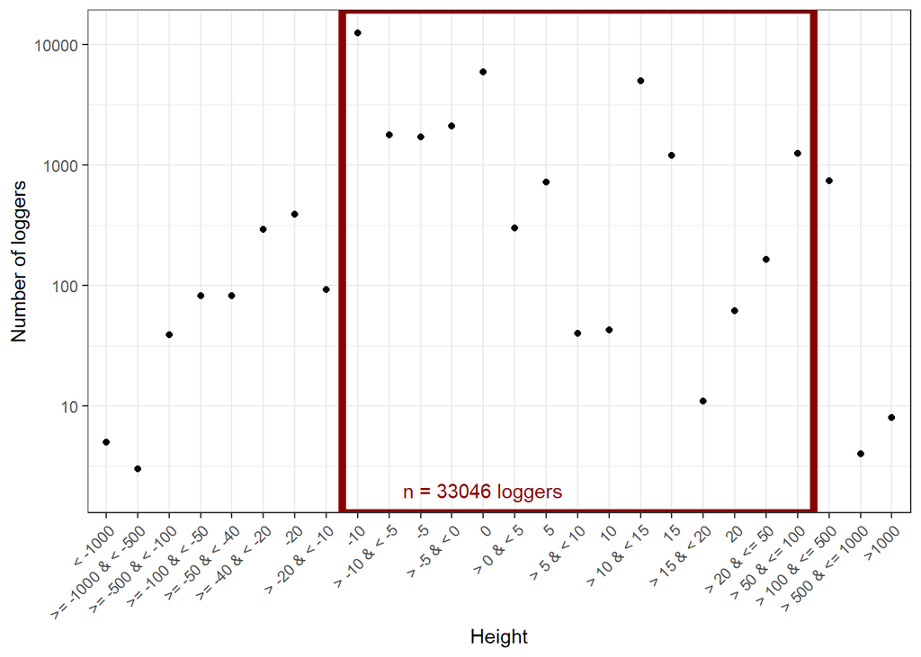

# Loggers time range selection

| duration | number.of.loggers |
| --- | --- |
| < 1 day | 185 |
| >= 1 day & < 1 month | 202 |
| >= 1 month & < 3 months | 757 |
| >= 3 months & < 6 months | 21064 |
| >= 6 months & < 1 year | 2444 |
| >= 1 year & < 5 years | 5617 |
| >= 5 years & < 10 years | 1151 |
| >= 10 years | 1533 |

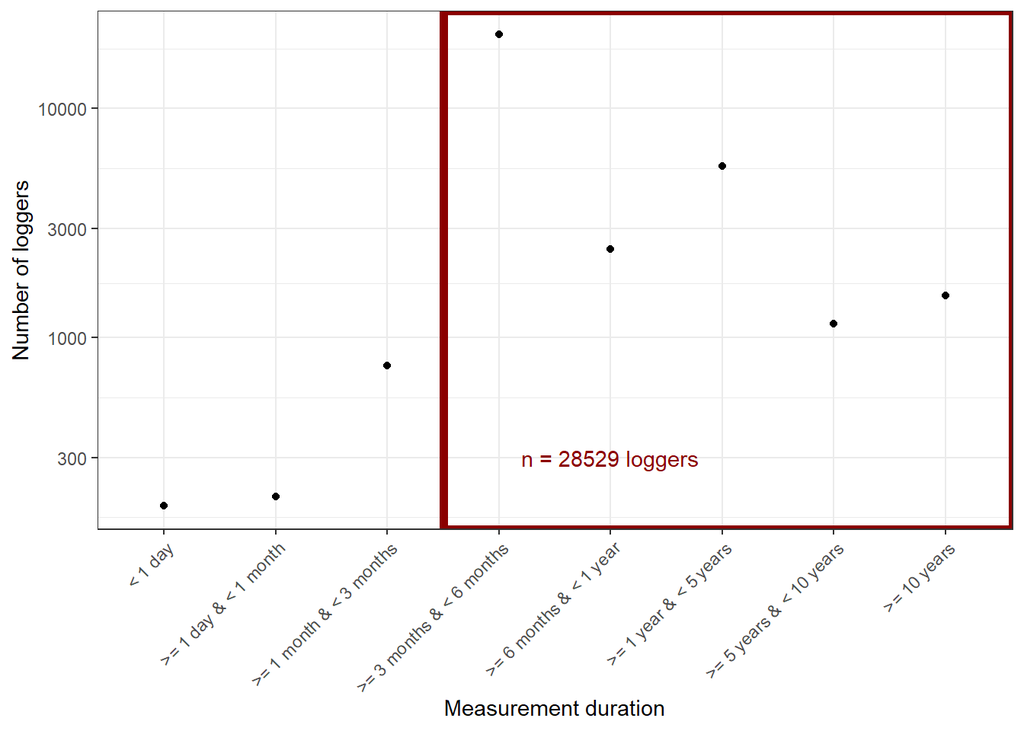

# Loggers distribution in space and biomes

## Beloground ( height >= -10cm & < 0cm)

blue dots are samples excluded during the loggers selection

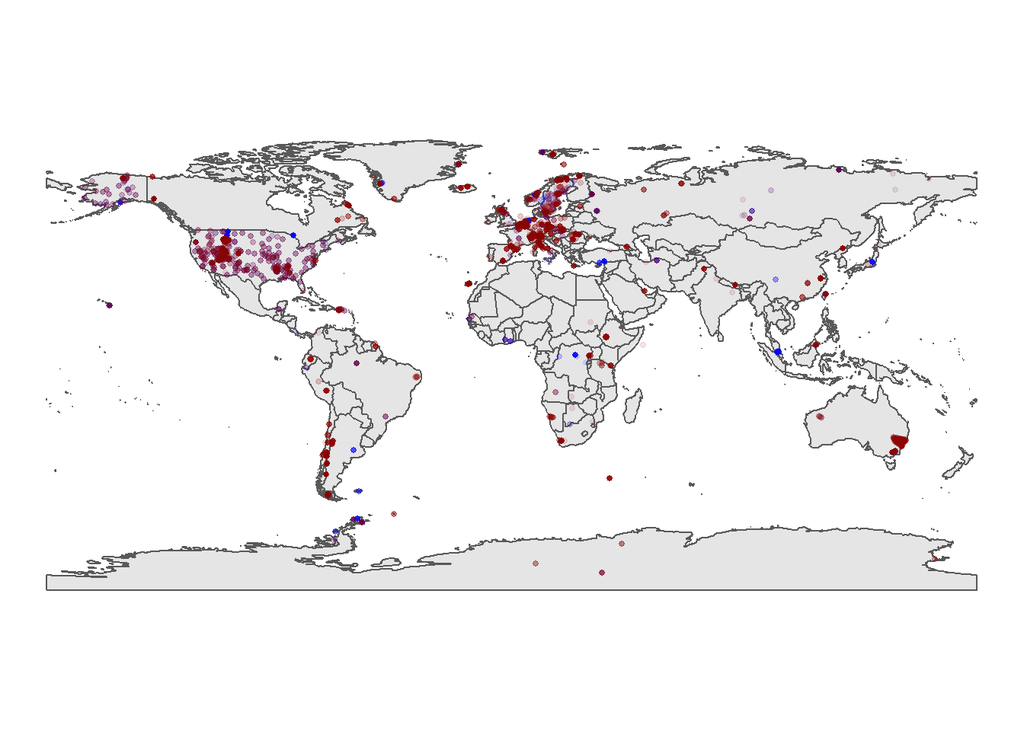

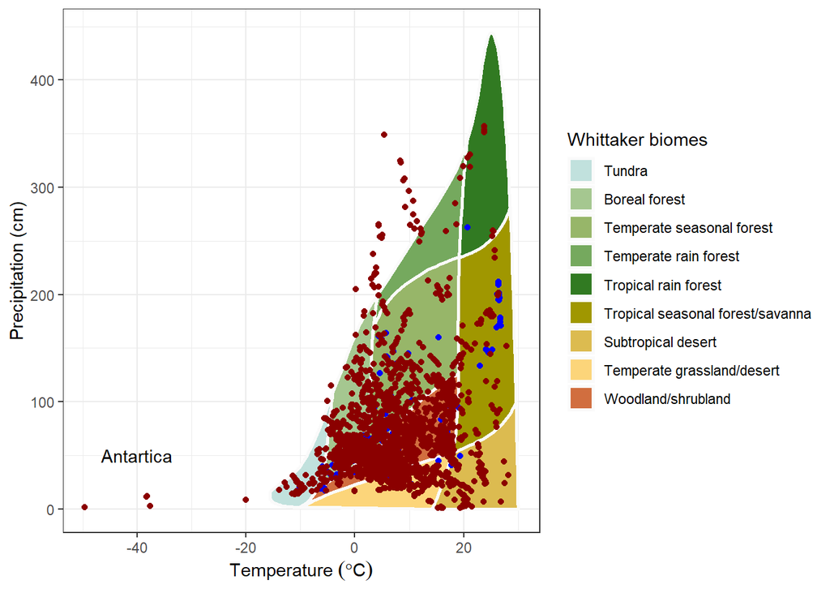

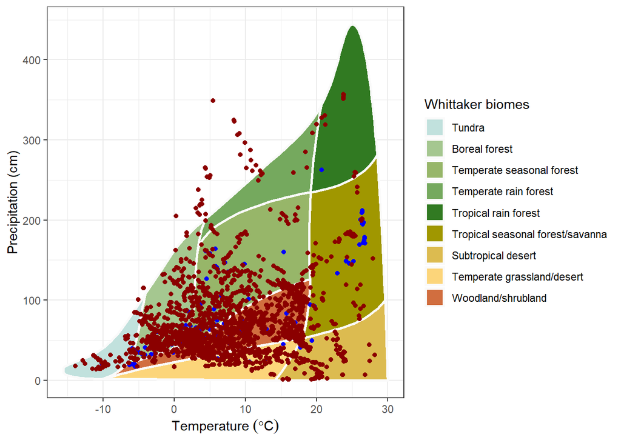

## Ground (height = 0cm)

blue dots are samples excluded during the loggers selection

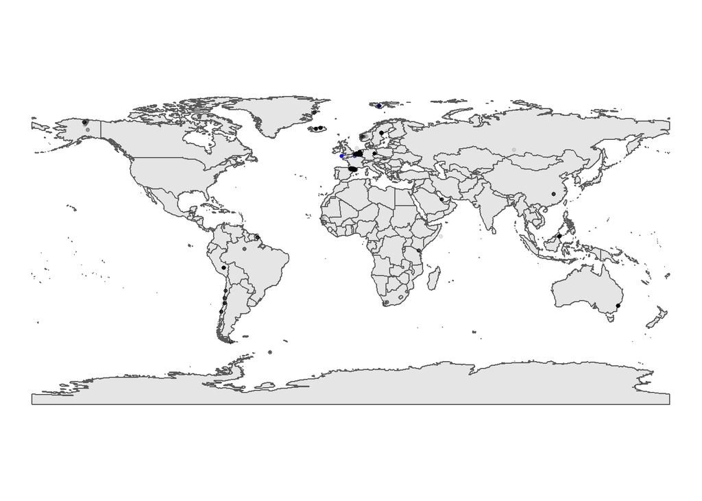

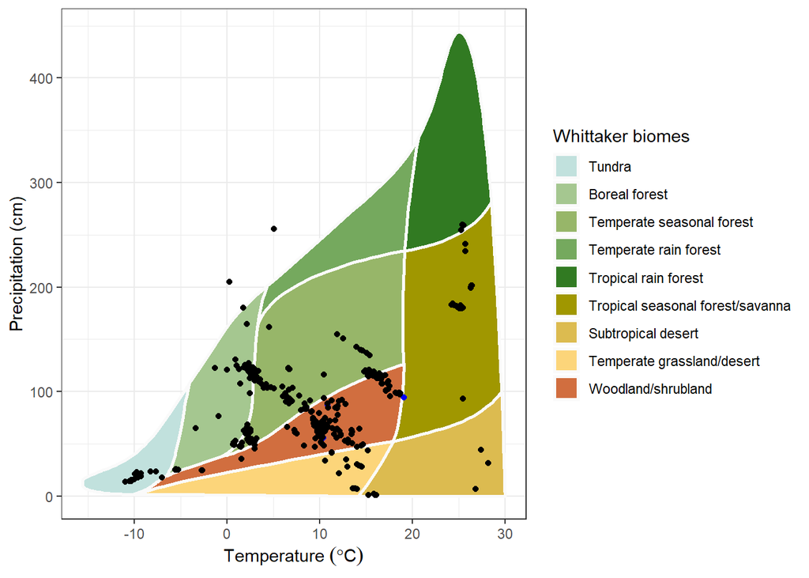

blue dots are samples excluded during the loggers selection

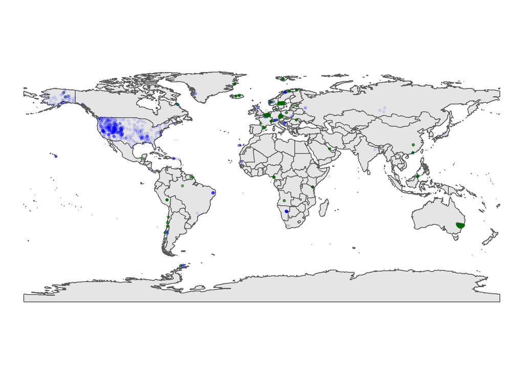

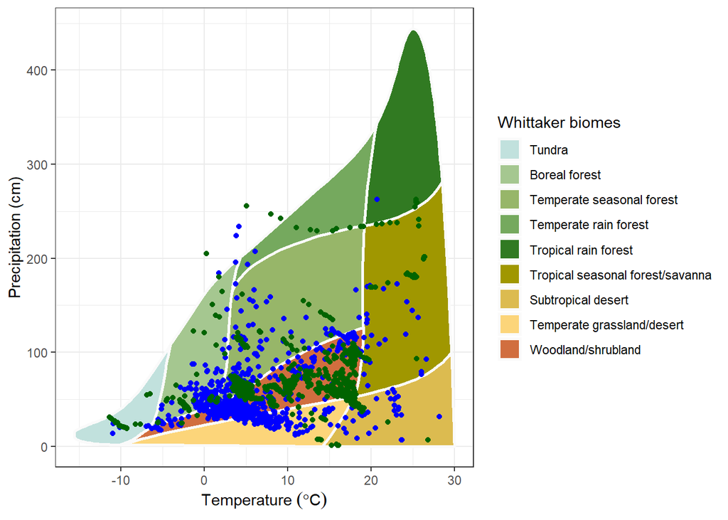

Samples lost have really short temporal coverage (less than three months)

# Highly sample area (focus belowground)

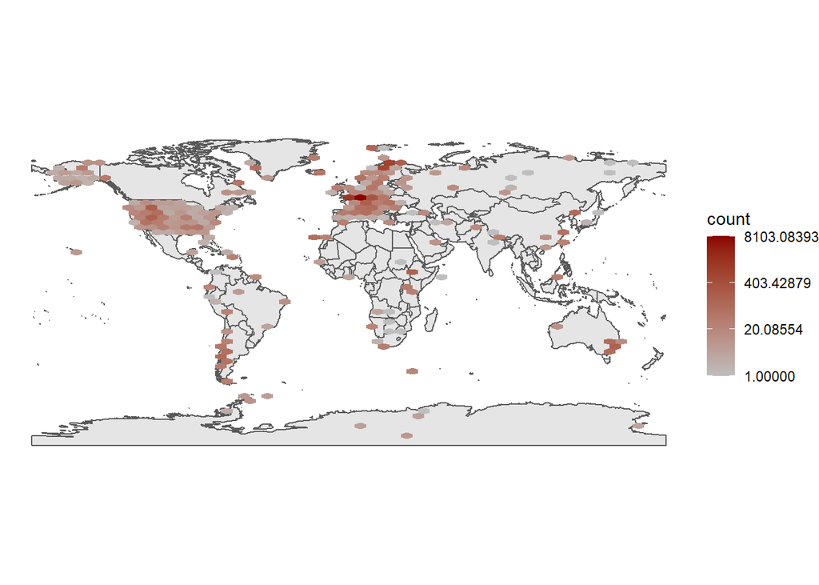

## Europe

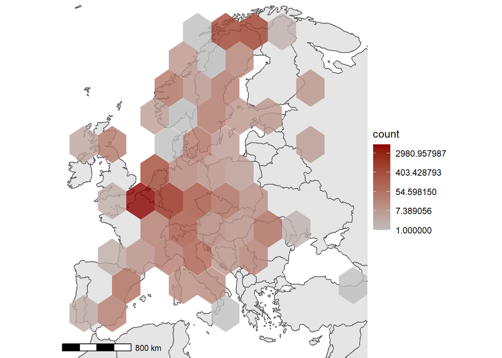

### Belgium

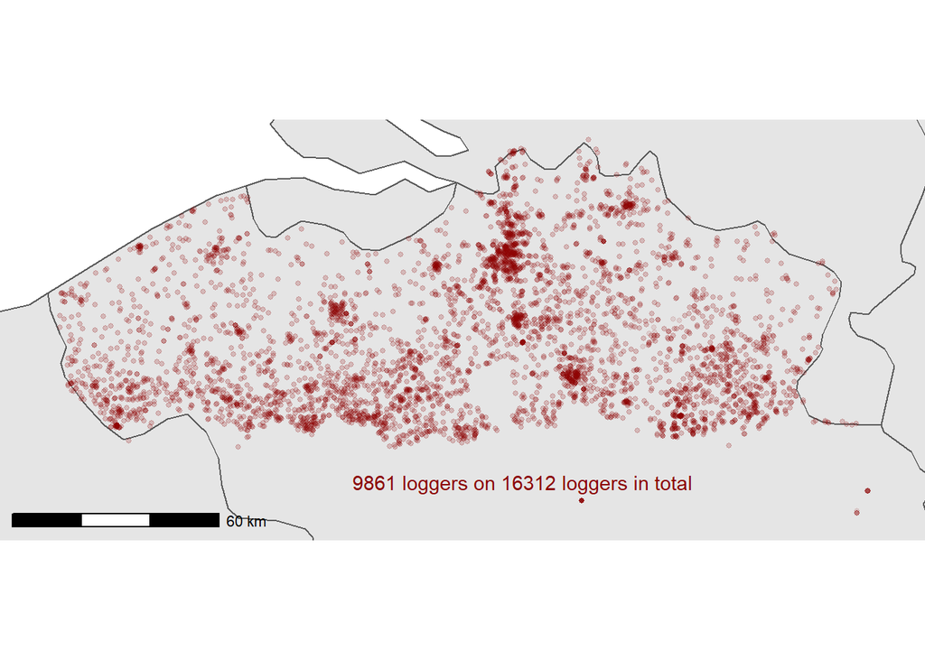

A strong re-sampling seems needed in order to reduce at least by 20 the density of loggers (keep 500 loggers).

Owners to this local sampling

```
## # A tibble: 25 x 5
## # Groups:   name, Full_metadata_all.Meta_data_open_access, height [14]
##    name                   Full_metadata_all.~ height time.range number.of.logge~
##    <chr>                  <chr>                <dbl> <drtn>                <int>
##  1 Dajana Radujkovic      Yes                     -5 421 days                  2
##  2 Jonas Lembrechts       <NA>                   -10 180 days               9586
##  3 Jonas Lembrechts - EWI Blurred_coordinate~     -8  92 days                 32
##  4 Jonas Lembrechts - EWI Blurred_coordinate~     -8  93 days                 10
##  5 Jonas Lembrechts - EWI Blurred_coordinate~     -8  95 days                 29
##  6 Jonas Lembrechts - EWI Blurred_coordinate~     -8  96 days                 59
##  7 Jonas Lembrechts - EWI Blurred_coordinate~     -8  97 days                 20
##  8 Jonas Lembrechts - EWI Blurred_coordinate~     -8 140 days                  3
##  9 Jonas Lembrechts - EWI Blurred_coordinate~     -8 145 days                  1
## 10 Jonas Lembrechts - EWI Blurred_coordinate~     -8 163 days                 10
## # ... with 15 more rows
```

Maybe subset from Jonas Lembrechts dataset + several years datasets (Miguel Portillo Estrada, Pieter De Frenne, Tanguy Manise). Need to check with Jonas if the height of Tanguy Manise is not in meters rather than centimeters

## US

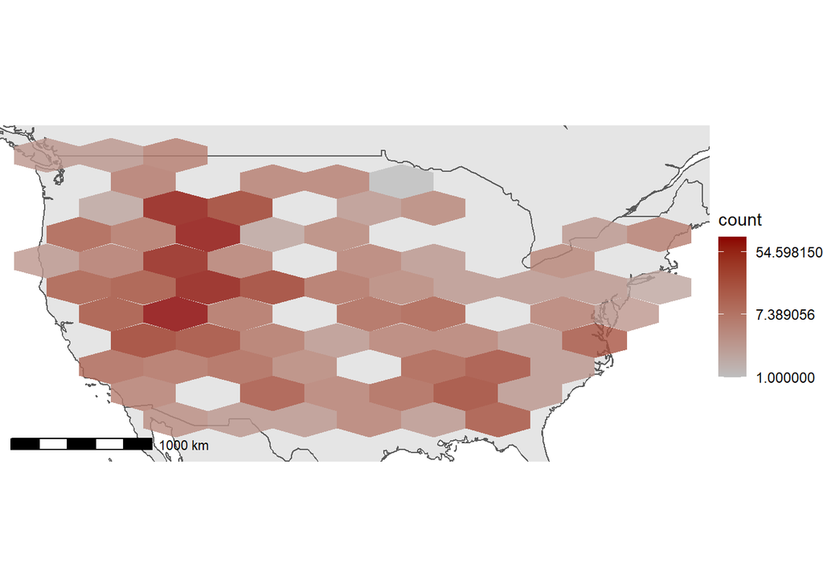

### UTAH

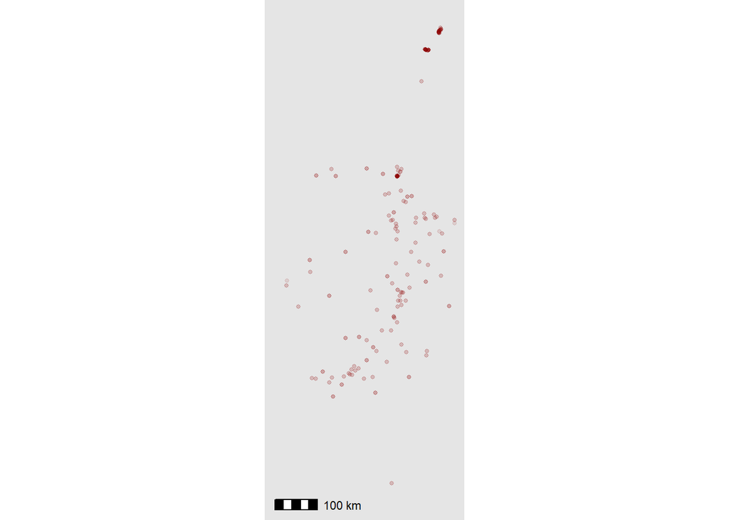

No resampling seems needed

## Autralia

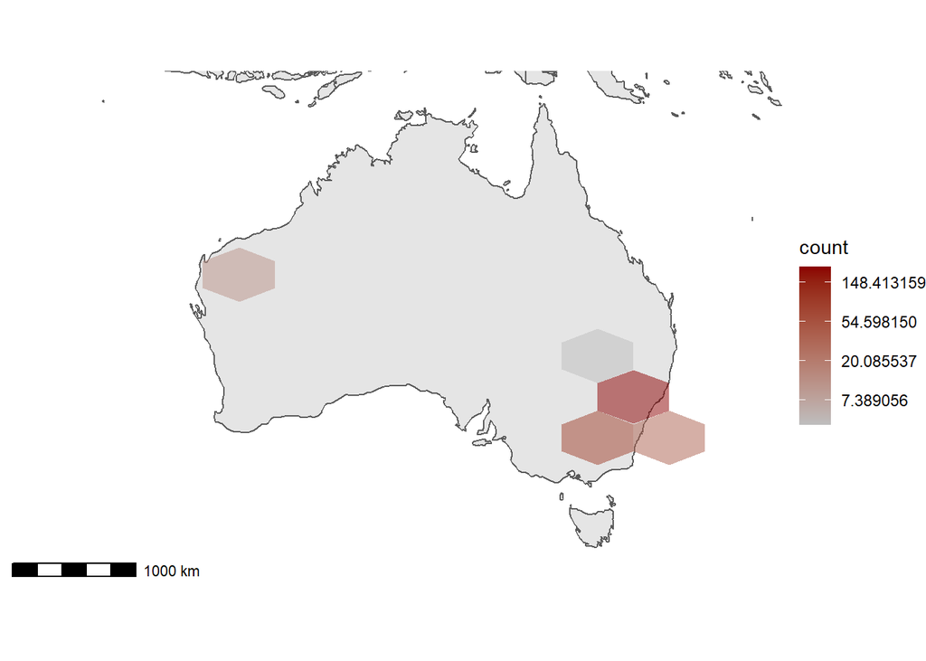

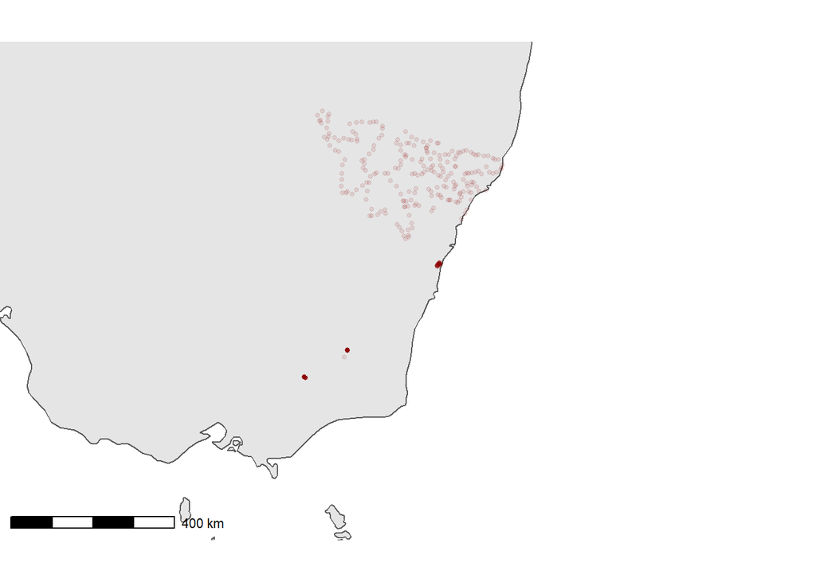

No resampling seems needed for now

# Final dataset

**Time range sampling:** Only select the loggers with records at least 3 months long

**Spatial subsampling:** Subsampling of Belgium by keeping 500 loggers for the entire region. Especially, Jonas loggers and all loggers with records longer than a year.

**Final dataset**

| Height | Loggers |
| --- | --- |
| >= 10 & < 0 | 6951 |
| = 0 | 744 |
| > 0 & <= 100 | 2073 |